# capture_rates

```python
from IPython.display import HTML

HTML('''<script>
code_show=true;
function code_toggle() {
 if (code_show){
 $('div.input').hide();
 } else {
 $('div.input').show();
 }
 code_show = !code_show
}
$( document ).ready(code_toggle);
</script>
<form action="javascript:code_toggle()"><input type="submit" value="Click here to toggle on/off the raw code."></form>''')
```

We estimate of capture rates between massive stars and/or BHs within the Galactic Center. There are a total of 250 massive stars with masses between 10 and 100 $M_{\odot}$ with an IMF $dN/dM \propto M^{-1.7}$. The (isotropic) radial density profile for the massive stars is

$$ n_{*}(r)= \begin{cases} 540 \left(\frac{r}{0.3 {\rm pc}}\right)^{-2.5} {\rm pc^{-3}} & 0.03 {\rm pc} \leq r\leq 0.3 {\rm pc}\\ 0 & {\rm Otherwise} \end{cases} $$

The density and (1D) velocity dispersion profiles of the BHs are taken from the Fiducial model in Generozov et al. 2018. They may be appoximated as .

$$ n(r)= \begin{cases} 2.8\times 10^4 \left(\frac{r}{0.2 {\rm pc}}\right)^{-2.5} {\rm pc^{-3}} & r\geq 0.2 {\rm pc}\\ 2.8\times 10^4 \left(\frac{r}{0.2 {\rm pc}}\right)^{-1.9} {\rm pc^{-3}} & r <0.2 {\rm pc} \end{cases} $$$$ \sigma(r) = 75 \left(\frac{r}{1 {\rm pc}}\right)^{-0.5} \,\,{\rm km s^{-1}} $$

The plots below compare analytic and numerical profiles. The (isotropic) velocity dispersion of the disk stars will be approximately equal to that of the BHs.

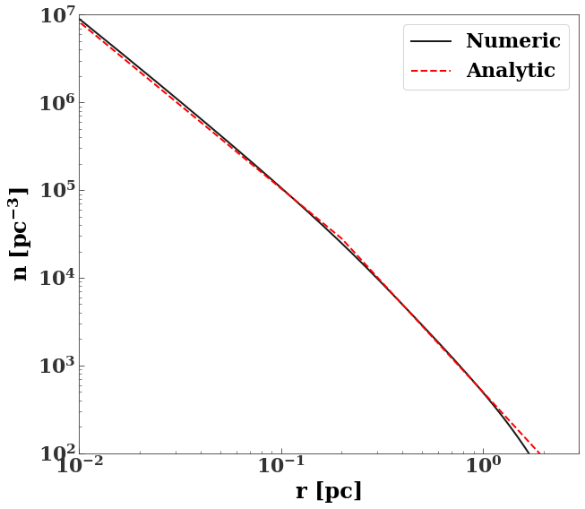

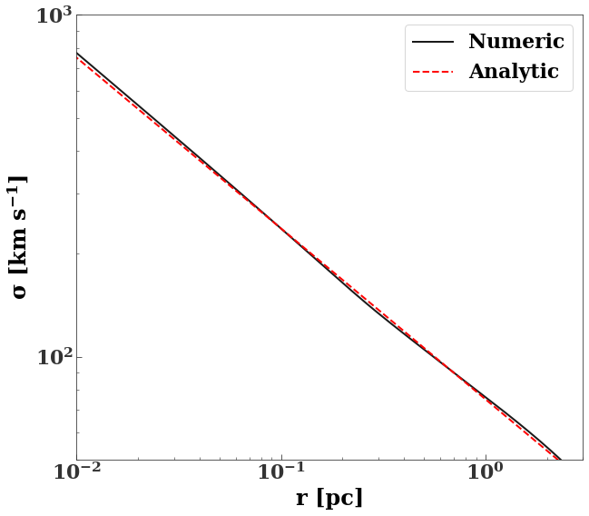

```python
import sys
sys.path.append('/home/aleksey/software/fJnew')
import agama_analyze
%pylab inline
import cgs_const as cgs

@np.vectorize
def fid_dens_fit(r):
    if r>=0.2:
        return 2.8e4*(r/0.2)**(-5./2.)
    else:
        return 2.8e4*(r/0.2)**(-1.9)

@np.vectorize
def fid_sig_fit(r):
    return 75.*(r)**-0.5

fig,ax=plt.subplots(figsize=(10,9))
ax.set_xlim(0.01, 3)
ax.set_ylim(1.0e2, 1.0e7)
ax.set_xlabel(r'r [pc]')
ax.set_ylabel(r'$n $ [pc$^{-3}$]')

dat=agama_analyze.read_agama_tab('/home/aleksey/Dropbox/thesis/tidal_capture/figure_runs_m0.3_new//fiducial_renorm/\
fid_nscombo_670b')
ax.loglog(dat['r'], dat['rho(r)']/10., label='Numeric')
ax.loglog(dat['r'], fid_dens_fit(dat['r']), 'r--', label='Analytic')
ax.legend()

fig,ax=plt.subplots(figsize=(10,9))
ax.set_xlim(0.01, 3)
ax.set_ylim(0.5e2, 1.0e3)
ax.set_xlabel(r'r [pc]')
ax.set_ylabel(r'$\sigma $ [km s$^{-1}$]')

ax.loglog(dat['r'], dat['VelDispersion']*(cgs.G*cgs.M_sun/cgs.pc)**0.5/1.0e5, label='Numeric')
ax.loglog(dat['r'], fid_sig_fit(dat['r']), 'r--', label='Analytic')
ax.legend()
```

The table below shows binary formation rate from tidal, grav. wave, 3-body capture. The stars are assumed to be in a disk configuration with H/R~0.1. Thus, the spatial density of stars is enhanced by a factor of (H/R)^-1 compared to the isotropized profile above. The velocity dispersion is reduced by this factor.

In rows that have a "BH (disk)" under "Species", the BHs are also assumed to be in a disk configuration.

We estimate the tidal capture rate using both the tidal coupling constants from linear theory and from Ivanov and Novikov 2001 (as in Generozov et al. 2018). Unfortunately latter may not be trust-worthy if the mass of the capturer is greater than or equal to the victim star...All of the massive stars are modelled as n=3 polytropes)

```python
from astropy.io import ascii
ascii.read('capture_rates.csv',delimiter=',')
```

<Table masked=True length=7>

| Process str14 | Species str25 | Rate float64 | Expected Number float64 | Notes str42 |
| --- | --- | --- | --- | --- |
| TC | Stars (Disk)-Stars (Disk) | 4.1e-07 | 4.1 | Equal mass |
| - | - | 3.8e-07 | 1.9 | Equal mass/Lin Theory |
| - | Stars (Disk)-BH | 2e-08 | 0.16 | -- |
| - | - | 1.1e-08 | 0.09 | Lin Theory |
| - | Stars (Disk)-BH (Disk) | 7.5e-06 | 50.0 | Lin Theory |
| GW Capture | BH (Disk)-BH (Disk) | 5e-07 | -- | (Using numerical profiles for convenience) |
| 3-body capture | BHs (Disk) | 3.7e-10 | -- | -- |